# Determining growth rates from IWYP field trials

A Bowerman, D Ganguly

19/06/2019

## Aim

Determine growth rates for IWYP field trials based on digital biomass (NDVI).

## Method

Utilise measures of Normalized Vegetation Index (NDVI, Greenseeker) to estimate growth rates using a nonlinear modelling approach [Paine et al 2012](https://besjournals.onlinelibrary.wiley.com/doi/full/10.1111/j.2041-210X.2011.00155.x).

Also see [Fitting von Bertalanffy Growth Function](http://rpubs.com/lacs/1123) and [fishR](http://derekogle.com/fishR/examples/oldFishRVignettes/VonBertalanffy.pdf).

## Results

As an initial exploratory exercise, we can produce a heatmap to look at individual growth behaviours.

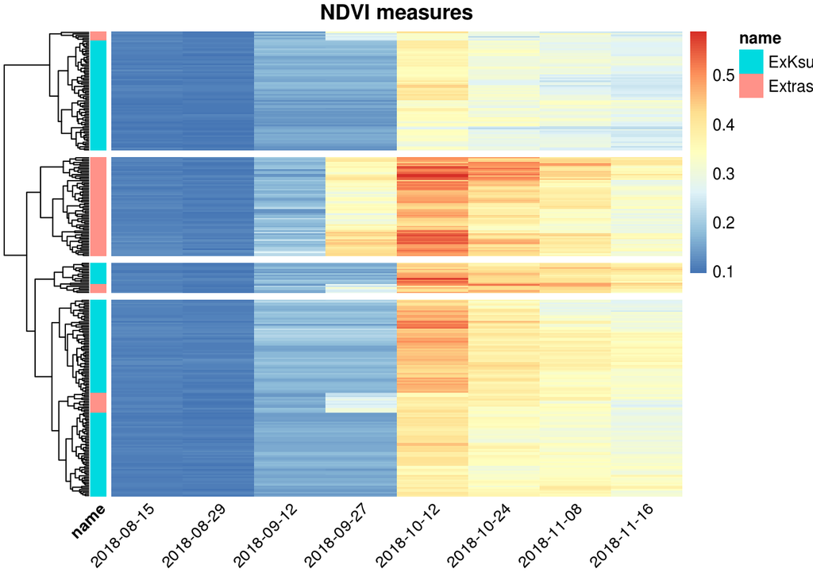

```r
library(pheatmap)

## make numeric matrix and heatmap
my_mat <- select(dat, germinatebase_id, date, value) %>% group_by(germinatebase_id,
    date) %>% summarise(avg = mean(value)) %>% spread(date, avg)

my_mat <- as.data.frame(my_mat)
rownames(my_mat) <- my_mat$germinatebase_id
my_mat <- as.matrix(my_mat[2:ncol(my_mat)])

# define accession annotations
my_grps <- select(accs, foreign_id, name)
my_grps <- subset(my_grps, foreign_id %in% rownames(my_mat))
rownames(my_grps) <- my_grps$foreign_id
my_grps$foreign_id <- NULL

pheatmap(mat = my_mat, show_rownames = F, main = "NDVI measures", annotation_row = my_grps,
    cutree_rows = 4, cluster_cols = FALSE, angle_col = 45)
```

We can arbitrarily group the data into 4 temporal patterns (cutree algorithm). Interestingly, the data doesn’t completely separate by panel.

We can also plot raw NDVI values with a generic loess polynomial fit.

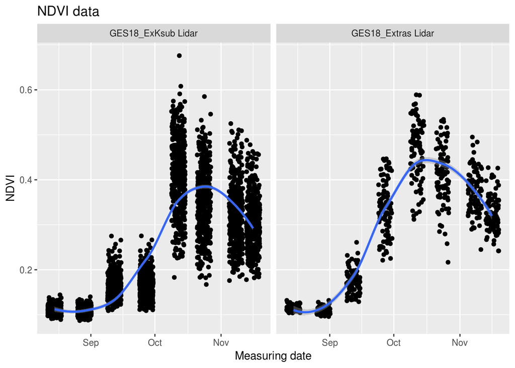

```r
library(ggplot2)
library(patchwork)

### plot jitter
ggplot(dat, aes(x = date, y = value)) + geom_jitter() + facet_wrap(~dataset) +
    geom_smooth(method = "loess") + scale_y_continuous(name = "NDVI") + scale_x_date(name = "Measuring date") +
    ggtitle("NDVI data") + theme(legend.position = "none")
```

Polynomial models are clearly *not* appropriate for plant growth modelling and are thus discouraged (Paine et al 2012). Instead, we will attempt to fit asymptotic non-linear models:

1. *3P logistic*
2. *4P logistic*
3. *Gompertz*

Which fitting routine to use [nls, *gnls*, or nlme]? If there are no treatment effects (ie y ~ x) use gnls. It can do everything that nls can do, but additionally allows variance modelling to deal with heteroscedasticity. Also, gnls allows you to choose which parameters should vary among treatment groups, and which should be global (Pinheiro & Bates, pg 401). However, occasionally gnls will fail to converge. In those cases, nls can still be useful. nlme can do all of the above, as well as allowing for fixed and (nested) random effects. However, it requires a somewhat different syntax for specifying the model (Pinheiro, J.C., and Bates, D.M. 2000).

## Trial models

We can first try fitting each of the above models to the data split up by plant_plot or accession IDs. Initially, exploratory modelling was performed on the entire NDVI data, however, convergence on this data is limited using *gnls* as we do not provide a means with which to account for the huge variance of data. Thus, we model individually and get a distribution of log likelihoods, as a measure of “goodness of fit”.

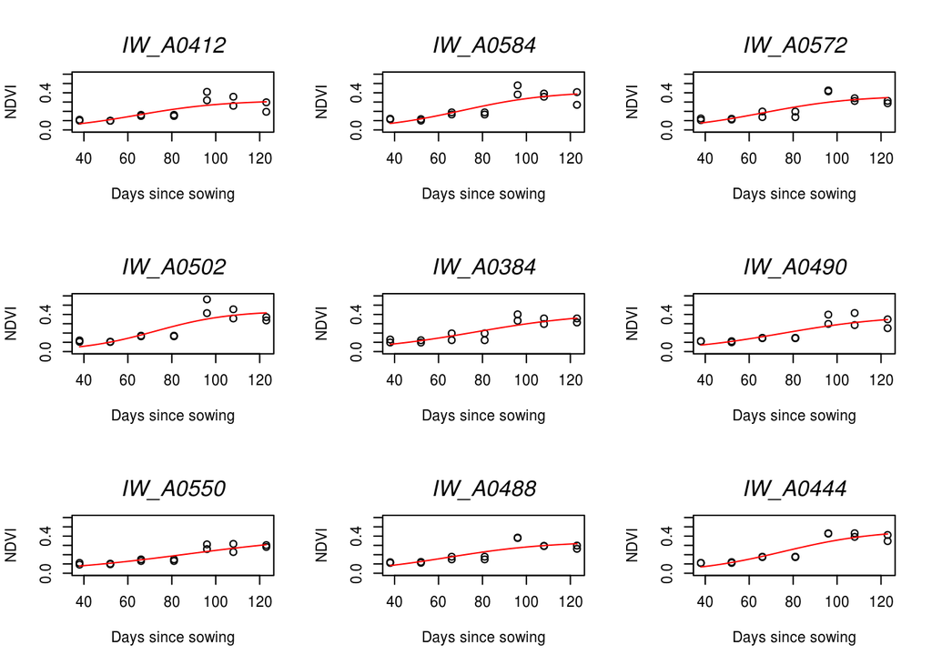

```r
par(mfrow = c(3, 3))

# plot and fit to 9 random accessions
for (i in sample(1:length(unique(df$ID)), size = 9, replace = FALSE)) {
    id <- unique(df$ID)[i]
    a <- subset(df, ID == id)

    # ERROR HANDLING for initial fit
    possibleError <- tryCatch(tmp <- getInitial(Y ~ SSlogis(X, Asym, xmid, scal),
        data = a), error = function(e) e)

    if (!inherits(possibleError, "error")) {
        tmp <- getInitial(Y ~ SSlogis(X, Asym, xmid, scal), data = a)
    }

    # ERROR HANDLING for final fit
    possibleError <- tryCatch(fit <- gnls(Y ~ SSlogis(X, Asym, xmid, scal),
        data = a, start = tmp), error = function(e) e)

    if (!inherits(possibleError, "error")) {
        # REAL WORK
        fit <- gnls(Y ~ SSlogis(X, Asym, xmid, scal), data = a, start = tmp)
        yfitted <- predict(fit, list(X = xNew))
        plot(Y ~ X, a, ylab = "NDVI", xlab = "Days since sowing", ylim = c(0,
            0.6))
        lines(xNew, yfitted, col = "red")
        mtext(paste(id), font = 3, padj = -1)
    }
}
```

```r
# get distribution of log likelihoods
log_lik_3p <- NULL

for (i in 1:length(unique(df$ID))) {
    id <- unique(df$ID)[i]
    a <- subset(df, ID == id)

    # ERROR HANDLING for initial fit
    possibleError <- tryCatch(tmp <- getInitial(Y ~ SSlogis(X, Asym, xmid, scal),
        data = a), error = function(e) e)

    if (!inherits(possibleError, "error")) {
        tmp <- getInitial(Y ~ SSlogis(X, Asym, xmid, scal), data = a)
    }

    # ERROR HANDLING for final fit
    possibleError <- tryCatch(fit <- gnls(Y ~ SSlogis(X, Asym, xmid, scal),
        data = a, start = tmp), error = function(e) e)

    if (!inherits(possibleError, "error")) {
        # REAL WORK
        fit <- gnls(Y ~ SSlogis(X, Asym, xmid, scal), data = a, start = tmp)
        log_lik_3p <- rbind(logLik(fit), log_lik_3p)
    }
}
```

```r
par(mfrow = c(3, 3))

# plot and fit to 9 random accessions
for (i in sample(1:length(unique(df$ID)), size = 9, replace = FALSE)) {
    id <- unique(df$ID)[i]
    a <- subset(df, ID == id)

    # ERROR HANDLING for initial fit
    possibleError <- tryCatch(tmp <- getInitial(Y ~ SSfpl(X, A, B, xmid, scal),
        data = a), error = function(e) e)

    if (!inherits(possibleError, "error")) {
        tmp <- getInitial(Y ~ SSfpl(X, A, B, xmid, scal), data = a)
    }

    # ERROR HANDLING for final fit
    possibleError <- tryCatch(fit <- gnls(Y ~ SSfpl(X, A, B, xmid, scal), data = a,
        start = tmp), error = function(e) e)

    if (!inherits(possibleError, "error")) {
        # REAL WORK
        fit <- gnls(Y ~ SSfpl(X, A, B, xmid, scal), data = a, start = tmp)
        yfitted <- predict(fit, list(X = xNew))
        plot(Y ~ X, a, ylab = "NDVI", xlab = "Days since sowing", ylim = c(0,
            0.6))
        lines(xNew, yfitted, col = "red")
        mtext(paste(id), font = 3, padj = -1)
    }
}

# get distribution of log likelihoods
log_lik_4p <- NULL

for (i in 1:length(unique(df$ID))) {
    id <- unique(df$ID)[i]
    a <- subset(df, ID == id)

    # ERROR HANDLING for initial fit
    possibleError <- tryCatch(tmp <- getInitial(Y ~ SSfpl(X, A, B, xmid, scal),
        data = a), error = function(e) e)

    if (!inherits(possibleError, "error")) {
        tmp <- getInitial(Y ~ SSfpl(X, A, B, xmid, scal), data = a)
    }

    # ERROR HANDLING for final fit
    possibleError <- tryCatch(fit <- gnls(Y ~ SSfpl(X, A, B, xmid, scal), data = a,
        start = tmp), error = function(e) e)

    if (!inherits(possibleError, "error")) {
        # REAL WORK
        fit <- gnls(Y ~ SSfpl(X, A, B, xmid, scal), data = a, start = tmp)
        log_lik_4p <- rbind(logLik(fit), log_lik_4p)
    }
}
```

[output not shown]

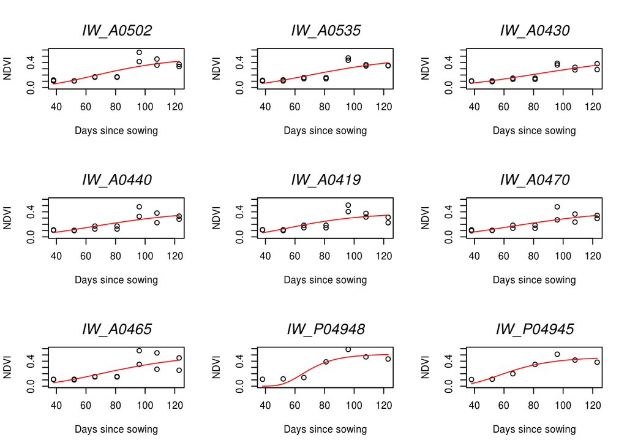

```r
par(mfrow = c(3, 3))

# plot and fit to 9 random accessions
for (i in sample(1:length(unique(df$ID)), size = 9, replace = FALSE)) {
    id <- unique(df$ID)[i]
    a <- subset(df, ID == id)

    # ERROR HANDLING for initial fit
    possibleError <- tryCatch(tmp <- getInitial(Y ~ SSgompertz(X, Asym, b2,
        b3), data = a), error = function(e) e)

    if (!inherits(possibleError, "error")) {
        tmp <- getInitial(Y ~ SSgompertz(X, Asym, b2, b3), data = a)
    }

    # ERROR HANDLING for final fit
    possibleError <- tryCatch(fit <- gnls(Y ~ SSgompertz(X, Asym, b2, b3), data = a,
        start = tmp), error = function(e) e)

    if (!inherits(possibleError, "error")) {
        # REAL WORK
        fit <- gnls(Y ~ SSgompertz(X, Asym, b2, b3), data = a, start = tmp)
        yfitted <- predict(fit, list(X = xNew))
        plot(Y ~ X, a, ylab = "NDVI", xlab = "Days since sowing", ylim = c(0,
            0.6))
        lines(xNew, yfitted, col = "red")
        mtext(paste(id), font = 3, padj = -1)
    }
}
```

```r
# get distribution of log likelihoods
log_lik_gom <- NULL

for (i in 1:length(unique(df$ID))) {
    id <- unique(df$ID)[i]
    a <- subset(df, ID == id)

    # ERROR HANDLING for initial fit
    possibleError <- tryCatch(tmp <- getInitial(Y ~ SSgompertz(X, Asym, b2,
        b3), data = a), error = function(e) e)

    if (!inherits(possibleError, "error")) {
        tmp <- getInitial(Y ~ SSgompertz(X, Asym, b2, b3), data = a)
    }

    # ERROR HANDLING for final fit
    possibleError <- tryCatch(fit <- gnls(Y ~ SSgompertz(X, Asym, b2, b3), data = a,
        start = tmp), error = function(e) e)

    if (!inherits(possibleError, "error")) {
        # REAL WORK
        fit <- gnls(Y ~ SSgompertz(X, Asym, b2, b3), data = a, start = tmp)
        log_lik_gom <- rbind(logLik(fit), log_lik_gom)
    }
}
```

Compare log-likelihoods across all models

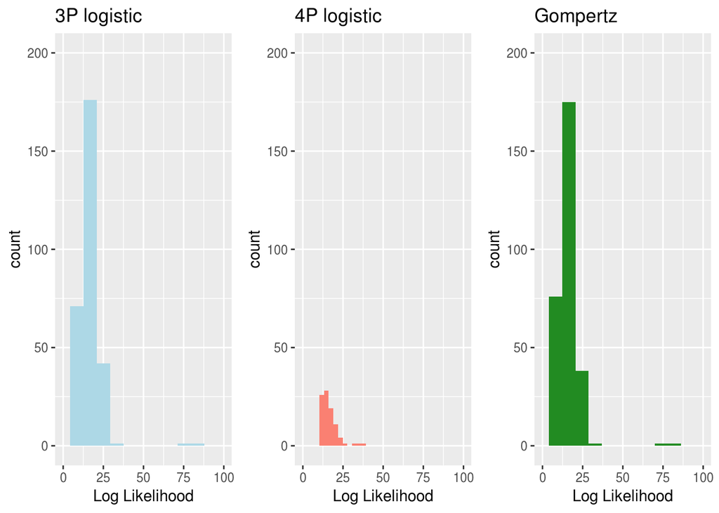

```r
log_p1 <- ggplot() + geom_histogram(aes(x = log_lik_3p), bins = 10, fill = "lightblue") +
    ggtitle("3P logistic") + scale_x_continuous("Log Likelihood") + coord_cartesian(ylim = c(0,
    200), xlim = c(0, 100))

log_p2 <- ggplot() + geom_histogram(aes(x = log_lik_4p), fill = "salmon", bins = 10) +
    ggtitle("4P logistic") + scale_x_continuous("Log Likelihood") + coord_cartesian(ylim = c(0,
    200), xlim = c(0, 100))

log_p3 <- ggplot() + geom_histogram(aes(x = log_lik_gom), fill = "forestgreen",
    bins = 10) + ggtitle("Gompertz") + scale_x_continuous("Log Likelihood") +
    coord_cartesian(ylim = c(0, 200), xlim = c(0, 100))

log_p1 + log_p2 + log_p3
```

> All models appear to perform similarly, however, 4P is extremely limited on convergence. 3P and Gompertz perform almost identically. Gompertz may be more appropriate as it does not rely on a constant growth rate over time/biomass, whereas 3P-logistic does. Therefore, continue with Gompertz.

### Parameter transformation equations

```r
# transform paramters of 3P logistic model
transform_param.logis <- function(coef) {
    K = coef[1]
    r = 1/(coef[3])
    M0 = K/(1 + exp(coef[2]/coef[3]))  #untransform best-fit parameters to K, r and M0
    if (is.data.frame(K)) {
        out <- cbind(K, r, M0)
    } else {
        out <- c(K, r, M0)
    }
    names(out) <- c("K", "r", "M0")
    return(out)
}

# transform parameters of Gompertz model
transform_param.gomp <- function(coef) {
    K <- coef[1]
    M0 <- K/exp(coef[2])
    r <- -log(coef[3])
    out <- c(K, r, M0)
    names(out) <- c("K", "r", "M0")
    return(out)
}
```

## Calculation of growth rates

Determine AGR, RGRm, and RGRt *per plot* (ie. using plot IDs = “_IW_P_XYZv“).

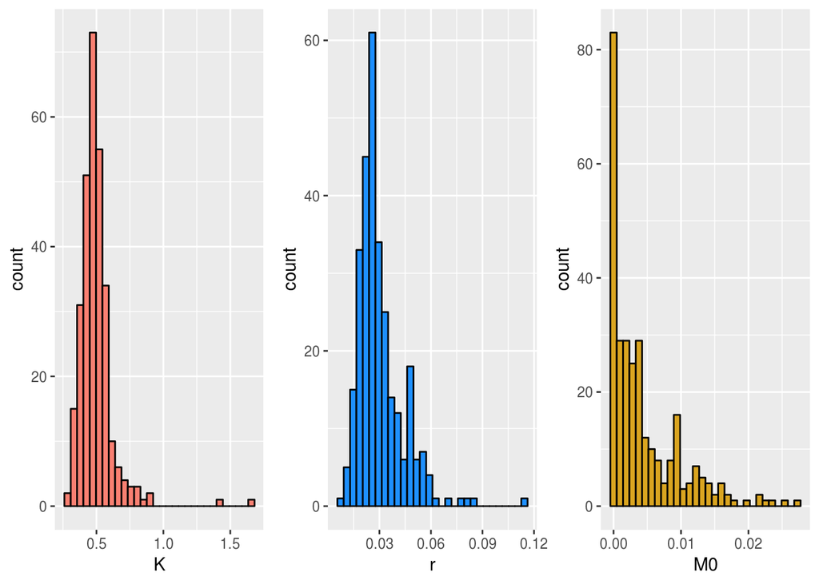

```r
cfs_logis <- NULL

for (i in 1:length(unique(df$ID))) {
    id <- unique(df$ID)[i]
    a <- subset(df, ID == id)

    # ERROR HANDLING for initial fit
    possibleError <- tryCatch(tmp <- getInitial(Y ~ SSgompertz(X, Asym, b2,
        b3), data = a), error = function(e) e)

    if (!inherits(possibleError, "error")) {
        tmp <- getInitial(Y ~ SSgompertz(X, Asym, b2, b3), data = a)
    }

    # ERROR HANDLING for final fit
    possibleError <- tryCatch(fit <- gnls(Y ~ SSgompertz(X, Asym, b2, b3), data = a,
        start = tmp), error = function(e) e)

    if (!inherits(possibleError, "error")) {
        # REAL WORK
        fit <- gnls(Y ~ SSgompertz(X, Asym, b2, b3), data = a, start = tmp)
        x <- transform_param.gomp(coef(fit))
        tmp2 <- tibble(id = id, K = x[1], r = x[2], M0 = x[3])
        cfs_logis <- rbind(cfs_logis, tmp2)
    }
}

p1 <- ggplot(data = cfs_logis) + geom_histogram(aes(x = K), fill = "salmon",
    colour = "black")
p2 <- ggplot(data = cfs_logis) + geom_histogram(aes(x = r), fill = "dodgerblue",
    colour = "black")
p3 <- ggplot(data = cfs_logis) + geom_histogram(aes(x = M0), fill = "goldenrod",
    colour = "black")

p1 + p2 + p3
```

```r
output_gomp <- cfs_logis %>% mutate(trial = df$dataset[match(id, df$ID)])
write_csv(output_gomp, "NLS_Gompertz_parameters.csv")
```

```r
rates <- NULL
cfs <- cfs_logis

for(i in cfs$id){
  tmp_rates <- tibble(
    id = i,
    K = cfs$K[cfs$id == i],
    M0 = cfs$M0[cfs$id == i],
    r = cfs$r[cfs$id == i],

    times = xNew,
    M  = K*((M0/K)^exp(-r*times)),
    AGR  = r*K*exp(-r*times)*log(K/M0)*(M0/K)^exp(-r*times),

    RGRt = AGR/M,
    RGRm = r*log(K/M)
  )

  rates <- rbind(rates, tmp_rates)
}

## growth rate examples
head(rates)
```

```
## # A tibble: 6 x 9
##   id            K          M0      r times      M     AGR   RGRt   RGRm
##   <chr>     <dbl>       <dbl>  <dbl> <dbl>  <dbl>   <dbl>  <dbl>  <dbl>
## 1 IW_P04899 0.445 0.000000136 0.0528  38   0.0590 0.00629 0.107  0.107
## 2 IW_P04899 0.445 0.000000136 0.0528  38.9 0.0646 0.00658 0.102  0.102
## 3 IW_P04899 0.445 0.000000136 0.0528  39.7 0.0703 0.00685 0.0974 0.0974
## 4 IW_P04899 0.445 0.000000136 0.0528  40.6 0.0763 0.00710 0.0931 0.0931
## 5 IW_P04899 0.445 0.000000136 0.0528  41.4 0.0825 0.00734 0.0889 0.0889
## 6 IW_P04899 0.445 0.000000136 0.0528  42.3 0.0889 0.00756 0.0850 0.0850
```

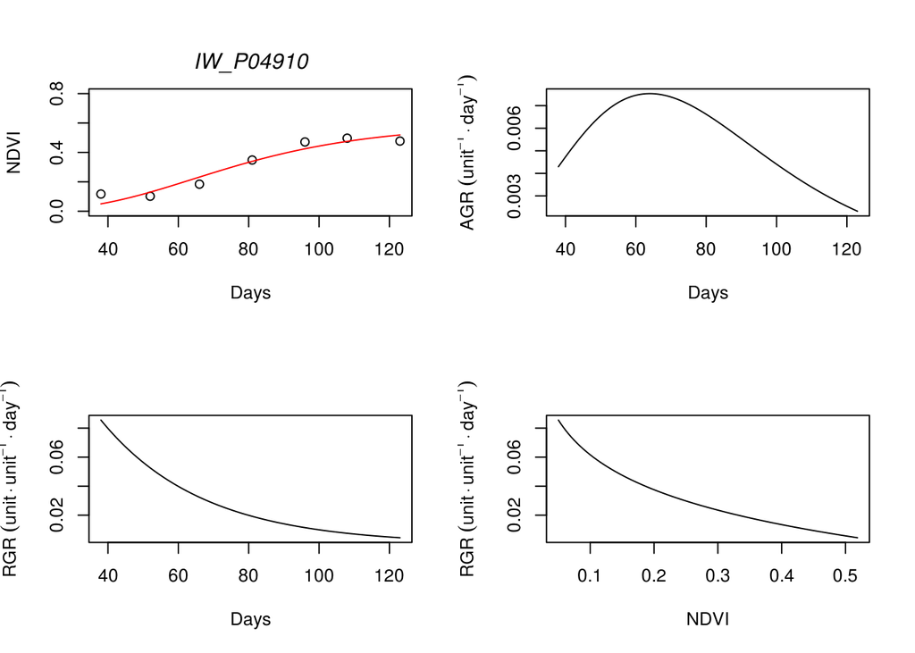

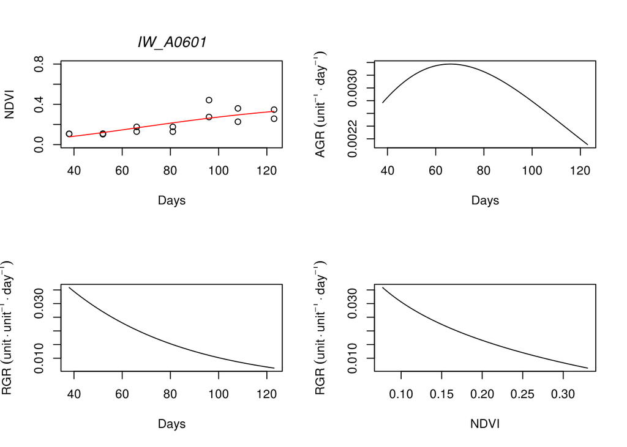

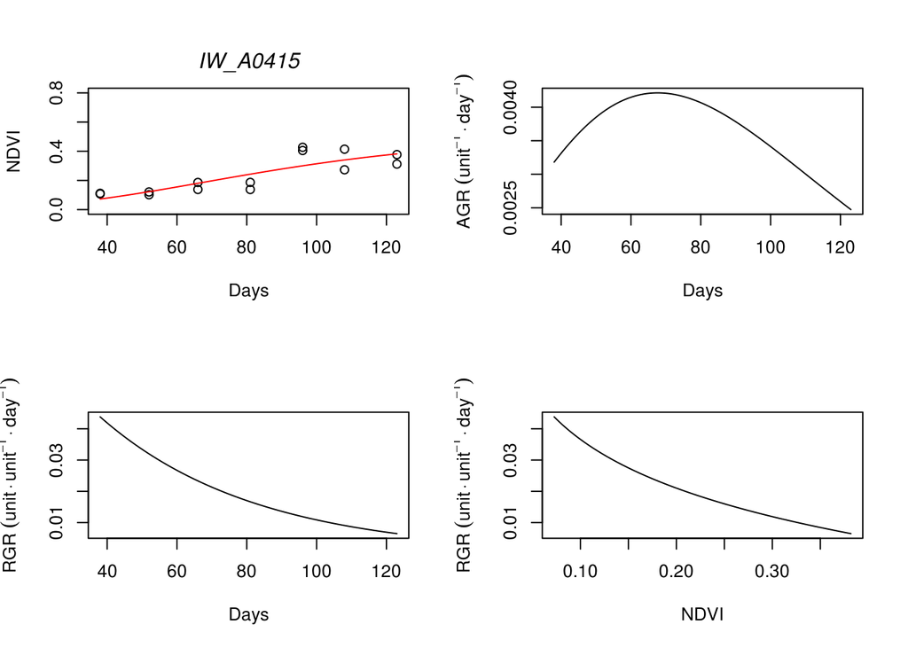

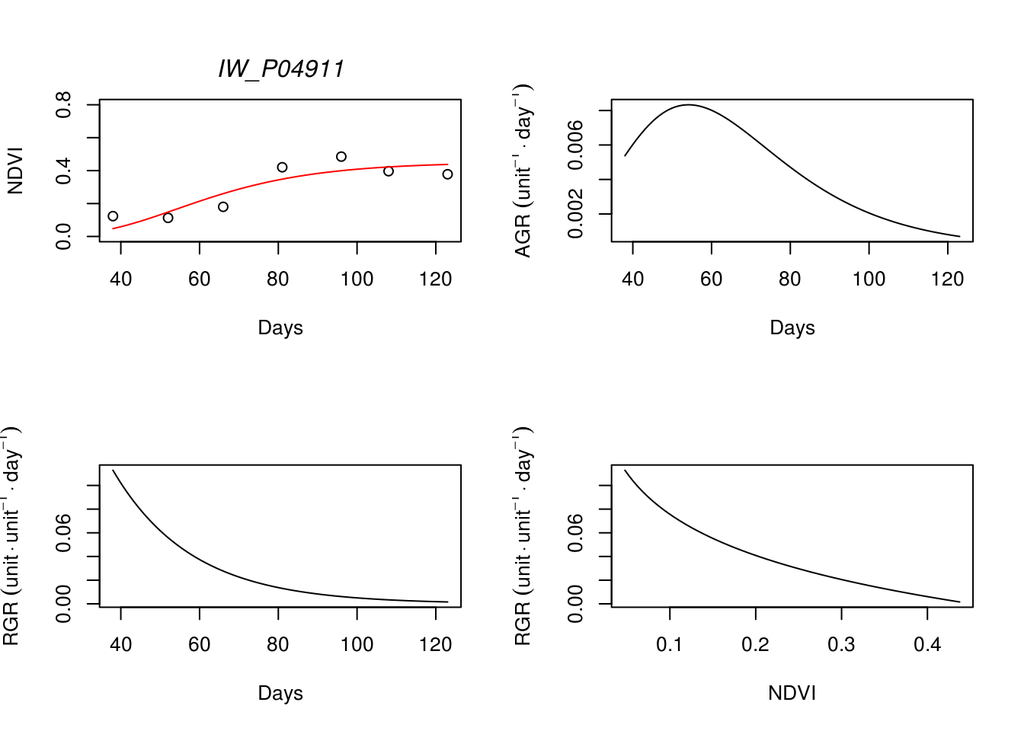

```r
write_csv(rates, "NLS_Gompertz_growth_rates.csv")

par(mfrow=c(2,2))

for(i in sample(1:length(unique(rates$id)), size = 4, replace = FALSE)){
  tryCatch({
      Id <- unique(df$ID)[i]
      a <- subset(df, ID == Id)

      tmp <- getInitial( Y ~ SSgompertz(X, Asym, b2, b3), data = a)
      fit  <- gnls( Y ~ SSgompertz(X, Asym, b2, b3), data = a, start = tmp)
      yfitted <- predict(fit, list(X = xNew))

      # "biomass"
      plot(Y ~ X, data = a, ylab = "NDVI", xlab = "Days", ylim = c(0,.8))
      lines(xNew, yfitted, col = 'red')
      mtext(paste(Id), font=3, padj = -1)

      b <- subset(rates, id == Id)

      # AGR
      plot(AGR ~ times, data=b, type = "n", xlab='Days', ylab = expression(paste("AGR ", (unit^-1%.%day^-1))))
      lines(AGR ~ times, data = b)

      # RGRt
      plot(RGRt ~ times, data=b, type = "n", xlab='Days', ylab = expression(paste("RGR ", (unit%.%unit^-1%.%day^-1))))
      lines(RGRt ~ times, data = b)

      # RGRm
      plot(RGRm ~ M, data=b, type = "n", xlab='NDVI', ylab = expression(paste("RGR ", (unit%.%unit^-1%.%day^-1))))
      lines(RGRm ~ M, data = b)
  },
  error = function(e){cat("ERROR @ #", i, ":", conditionMessage(e), "\n")})

}
```